# Classification Metrics

Author

David Melchor

## Introduction

The objective of this assignment is to analyze the performance of a binary classification model and develop intuition for how probability thresholds affect model evaluation metrics.

## Packages and Data Loading

```r
# Loading packages
pacman::p_load(rio, tidyverse, scales, knitr, kableExtra)
```

```r
# Use the raw version of the GitHub URL
url <- "https://raw.githubusercontent.com/acatlin/data/refs/heads/master/penguin_predictions.csv"

# Import CSV data directly into a data frame
penguin <- import(url)

# Inspect the dataset
glimpse(penguin)
```

```
Rows: 93
Columns: 3
$ .pred_female <dbl> 0.99217462, 0.95423945, 0.98473504, 0.18702056, 0.9947012…
$ .pred_class  <chr> "female", "female", "female", "male", "female", "female",…
$ sex          <chr> "female", "female", "female", "female", "female", "female…
```

```r
# Recode sex variable
penguin <- penguin |>
  mutate(
    sex = recode(sex,
      "female" = "Female",
      "male" = "Male"
    )
  )
```

## Null Error Rate

The **Null Error Rate** is the rate that predicts the majority class for every single observation in the dataset. It tells you: *“If I don’t build a machine learning model at all and just guess the most common outcome every single time, how often will I be wrong?*

```r
# look for counts
  og_penguin <- penguin |>
  count(sex) |>
  mutate(
    percent = round((n / sum(n)) * 100, 1))
```

In the `penguin` dataset, there are 39 female, and 54 male penguins.

Majority class is (`Male`): 54/93 = 58.1%

Minority class is (`Female`): 39/93 = 41.9%

So the **Null Error Rate** is 41.9%

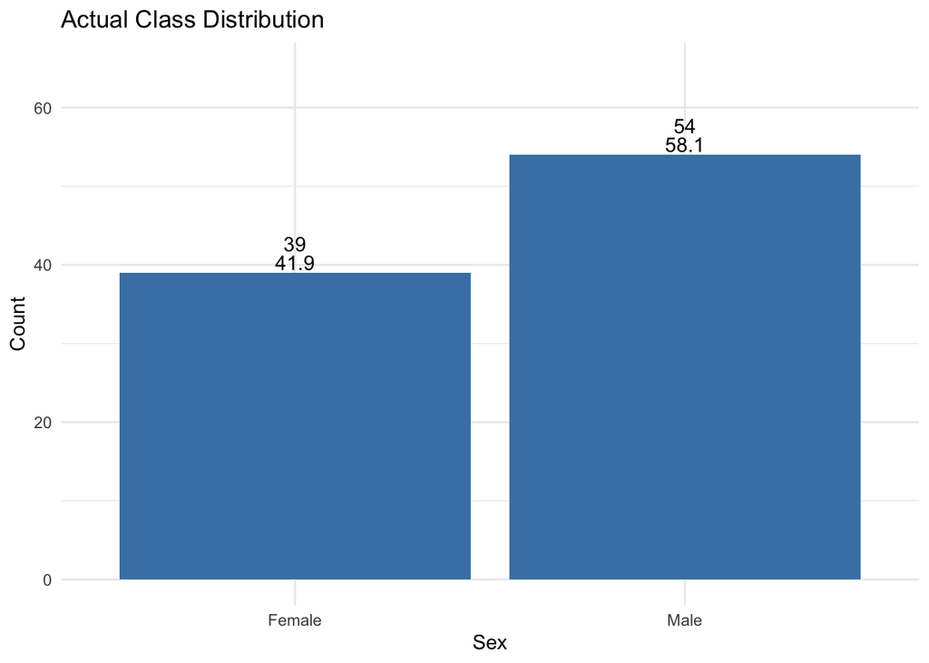

```r
og_penguin |>
ggplot(aes(
  x = sex,
  y = n)) +
  geom_col(fill = "steelblue") +
  # Add count label just above the bar
  geom_text(aes(
    label = n),
    vjust = -1.5) +
  # Add percentage label right below the count label
  geom_text(aes(
    label = percent),
    vjust = -0.2) +
    ylim(0, 65) +
  labs(
    title = "Actual Class Distribution",
    x = "Sex",
    y = "Count"
  ) +
  theme_minimal()
```

## Confusion Matrices at Multiple Thresholds

**True Positives (TP)** are the cases when the actual class of the data point was True and the predicted is also True.

**True Negatives (TN)** are the cases when the actual class of the data point was False and the predicted is also False.

**False Positives (FP)** are the cases when the actual class of the data point was False and the predicted is True. False because the model predicted incorrectly and Positive because the class is correct or positive.

**False Negatives (FN)** are the cases when the actual class of the data point was True and the predicted was False. False because the model predicted incorrectly and Negative because the class is correct, or negative.

```r
threshold <- penguin |>
  mutate(
    pred_02 = case_when(
    .pred_female > 0.2 ~ "Female",
    TRUE ~ "Male"
  ),
  pred_05 = case_when(
    .pred_female > 0.5 ~ "Female",
    TRUE ~ "Male"
  ),
  pred_08 = case_when(
    .pred_female > 0.8 ~ "Female",
    TRUE ~ "Male"
  ))
```

## Probability Threshold of 0.2

```r
threshold_02 <- threshold |>
  count(sex, pred_02) |>
  select(sex, pred_02, n) |>
  pivot_wider(
    names_from = pred_02,
    values_from = n,
    values_fill = 0
  )
```

```r
# Make summary table for pred_02
threshold_02 |>
  kbl(
    caption = "Table 1. Confusion Matrix at 0.2 Treshhold",
    col.names = c("Actual", "Pred Female", "Pred Male"),
    align = c("l", "c", "c")
  ) |>
  kable_styling(
    bootstrap_options = c("striped", "hover", "condensed", "responsive"),
    full_width = FALSE,
    position = "center"
  ) |>
  column_spec(1, bold = TRUE)
```

Table 1. Confusion Matrix at 0.2 Treshhold

| Actual | Pred Female | Pred Male |
| --- | --- | --- |
| Female | 37 | 2 |
| Male | 6 | 48 |

**TP:** 37

**TN:** 48

**Null Error Rate (37/93):** 39.7%

### Accuracy

Accuracy is the number of correct predictions made by the model over all predictions made.

**Accuracy = (TP + TN) / (TP + FP + FN + TN)**

```r
acc_02 <-
  (37 + 48) / (37 + 2 + 6 + 48)

round((acc_02 * 100), 1)
```

```
[1] 91.4
```

### Precision

Precision tells us the proportion of positive predictions that were actually correct. It answers: “*When the model predicts positive, how often is it right?“*

**Precision = TP / (TP + FP)**

```r
prec_02 <-
  37 / (37 + 2)

round((prec_02 * 100), 1)
```

```
[1] 94.9
```

### Recall

Recall is the proportion of actual positive cases that the model correctly identified. It answers: *“Out of all the real positive cases, how many did the model catch?”*

**Recall = TP / (TP + FN)**

```r
rec_02 <-
  37 / (37 + 6)

round((rec_02 * 100), 1)
```

```
[1] 86
```

### F1 Score

The harmonic mean of precision and recall. It measures a model’s overall predictive accuracy.

**F1 Score = 2 * (Precision * Recal) / (Precision + Recall)**

```r
f1_score_02 <-
  2 * ((prec_02 * rec_02) / (prec_02 + rec_02))

f1_score_02
```

```
[1] 0.902439
```

## Probability Threshold of 0.5

```r
threshold_05 <- threshold |>
  count(sex, pred_05) |>
  select(sex, pred_05, n) |>
  pivot_wider(
    names_from = sex,
    values_from = n,
    values_fill = 0
  )
```

```r
# Make summary table for pred_05
threshold_05 |>
kbl(
  caption = "Table 2. Confusion Matrix at 0.5 Threshhold",
  col.names = c("Actual", "Pred Female", "Pred Male"),
  align = c("l", "c", "c")
) |>
  kable_styling(
    bootstrap_options = c("striped", "hover", "condensed", "responsive"),
    full_width = FALSE,
    position = "center"
  ) |>
  column_spec(1, bold = TRUE)
```

Table 2. Confusion Matrix at 0.5 Threshhold

| Actual | Pred Female | Pred Male |
| --- | --- | --- |
| Female | 36 | 3 |
| Male | 3 | 51 |

**TP:** 36

**FP:** 3

**TN:** 51

**FN:** 3

**Null Error Rate (36/93):** 38.7%

### Accuracy

**Accuracy = (TP + TN) / (TP + FP + FN + TN)**

```r
acc_05 <-
  (36 + 51) / (36 + 3 + 3 + 51)

round((acc_05 * 100), 1)
```

```
[1] 93.5
```

### Precision

**Precision = TP / (TP + FP)**

```r
prec_05 <-
  36 / (36 + 3)

round((prec_05 * 100), 1)
```

```
[1] 92.3
```

### Recall

**Recall = TP / (TP + FN)**

```r
rec_05 <-
  36 / (36 + 3)

round((rec_05 * 100), 1)
```

```
[1] 92.3
```

### F1 Score

**F1 Score = 2 * (Precision * Recall) / (Precision + Recall)**

```r
f1_score_05 <-
  2 * ((prec_05 * rec_05) / (prec_05 + rec_05))

f1_score_05
```

```
[1] 0.9230769
```

## Probability Threshold of 0.8

```r
threshold_08 <- threshold |>
  count(sex, pred_08) |>
  select(sex, pred_08, n) |>
  pivot_wider(
    names_from = sex,
    values_from = n,
    values_fill = 0
  )
```

```r
threshold_08 |>
  kbl(
    caption = "Table 3. Confusion Matrix at 0.8 Threshhold",
    col.names = c("Actual", "Pred Female", "Pred Male"),
    align = c("l", "c", "c")
  ) |>
  kable_styling(
    bootstrap_options = c("striped", "hover", "condensed", "responsive"),
    full_width = FALSE,
    position = "center"
  ) |>
  column_spec(1, bold = TRUE)
```

Table 3. Confusion Matrix at 0.8 Threshhold

| Actual | Pred Female | Pred Male |
| --- | --- | --- |
| Female | 36 | 2 |
| Male | 3 | 52 |

**TP:** 36

F**P:** 2

**TN:** 52

**FN:** 3

**Null Error Rate (36/93):** 38.7%

### Accuracy

**Accuracy = (TP + TN) / (TP + FP + FN + TN)**

```r
acc_08 <-
  (36 + 52) / (36 + 2 + 3 + 52)

round((acc_08 * 100), 1)
```

```
[1] 94.6
```

### Precision

**Precision = TP / (TP + FP)**

```r
prec_08 <-
  36 / (36 + 2)

round((prec_08 * 100), 1)
```

```
[1] 94.7
```

### Recall

**Recall = TP / (TP + FN)**

```r
rec_08 <-
  36 / (36 + 3)

round((rec_08 * 100), 1)
```

```
[1] 92.3
```

### F1 Score

**F1 Score = 2 * (Precision * Recall) / (Precision + Recall)**

```r
f1_score_08 <-
  2 * ((prec_08 * rec_08) / (prec_08 + rec_08))

f1_score_08
```

```
[1] 0.9350649
```

## Threshold Use Cases

Choosing which threshold to use, 0.2 or 0.8 come down to what type of error someone is more willing to commit, missing a positive case, or raising a false alarm.

### A 0.2 Threshold

Using a lower threshold is used in a scenario where it’s more important to catch as many positive cases as possible, even if it means tolerating false alarms. In the cases of a rare or deadly diseases where treatment time is crucial for survival, we may need to lower the threshold to ensure the model flags anyone with the probability of having the disease

### A 0.8 Threshold

Using a higher threshold is used in a scenario where accuracy is more important. In the case of an app that automatically moves emails straight to the trash folder, we might want to be more strict about making sure that the system is not deleting emails that actually important. Using a threshold of 0.8 in this situation would mean that the app will only delete an email if it is 80% sure that it is junk. If it is not sure, then the email would stain in the inbox.